# Meeting 04/05

```python
# load dataset
dataset = fo.load_dataset("dugong")
```

```python
## load views
nc_view = dataset.load_saved_view('nc')
wp_view = dataset.load_saved_view('wp')

## load saved test view
test_view_seed0 = dataset.load_saved_view('wp_test_s0')
test_view_seed63 = dataset.load_saved_view('wp_test_s63')
```

# Pipeline

How the West Papua was partitioned and process for each seed

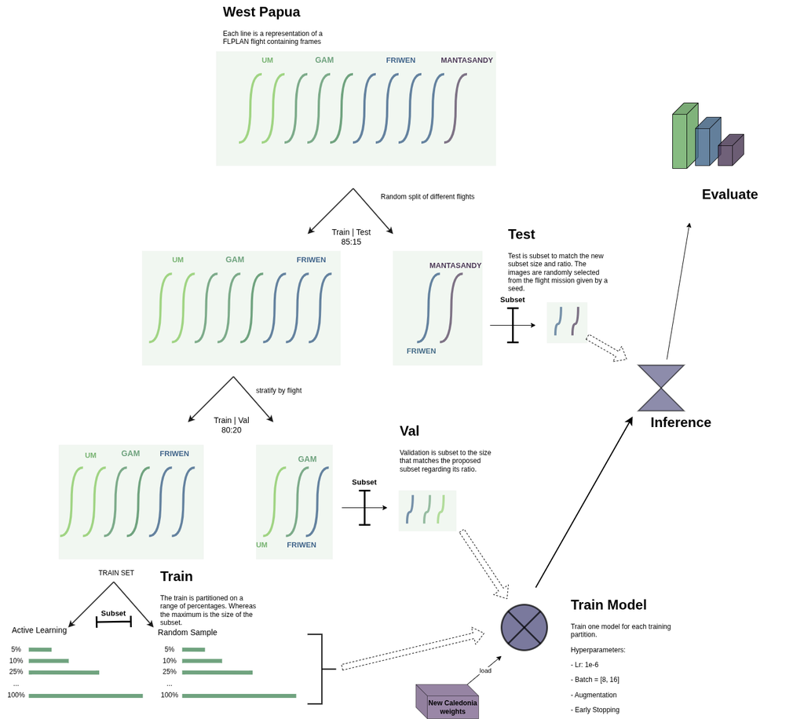

```python
## Which are the flight missions used for test on seed 0?
print(f"Number of iamges on test size:{len(test_view_seed0)}")
test_view_seed0.distinct('stratify_key')
```

```
Number of iamges on test size:103
```

```
['WP_FRIWEN_FRIWEN_M12', 'WP_FRIWEN_FRIWEN_M53', 'WP_MANTASANDY_MANTASANDY_M5']
```

# Recalling Active Learning

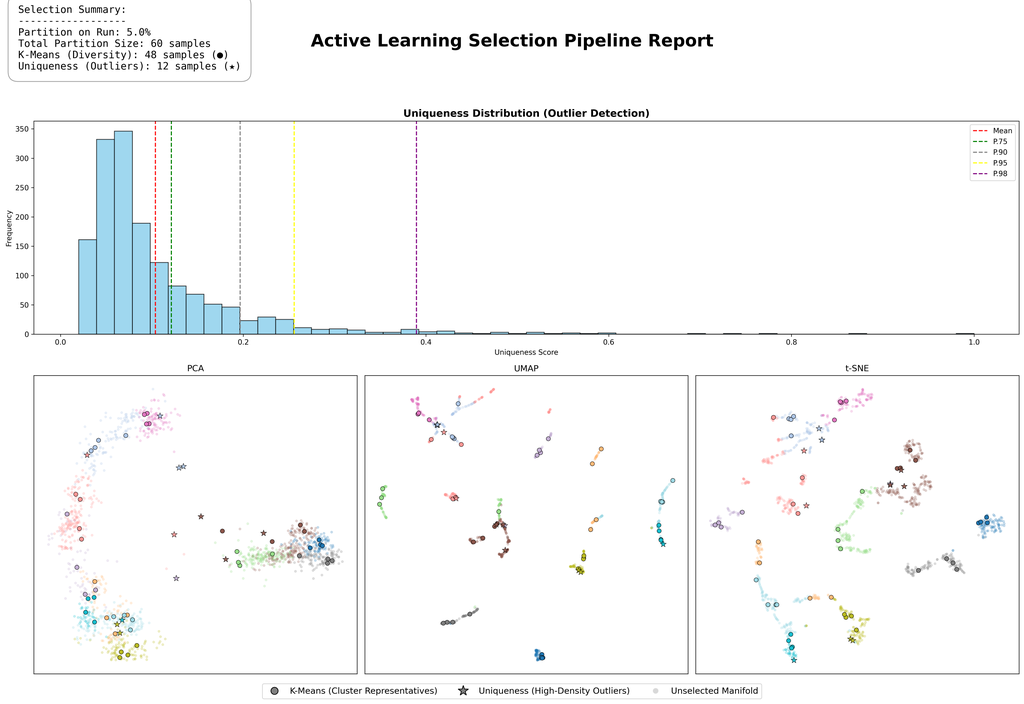

# Current State

- The IRISA cluster has been in high-demand use last week.
- 3 seeds were selected to be processed and therefore assessed however only 2 seeds had complet the full run. Still managing to run the last seed.
- SEED0 - OK
- SEED63 - OK (PARCIAL)
- SEED72 - ON RUNNING

```python
dataset.distinct("tags")
```

```
['notin_TEST_0',
 'notin_TEST_63',
 'notin_TEST_72',
 'notin_val_0',
 'notin_val_63',
 'notin_val_72',
 'test_0',
 'test_63',
 'test_72',
 'train_0',
 'train_63',
 'train_72',
 'val_0',
 'val_63',
 'val_72']
```

```python
## load the views
nc_view = dataset.load_saved_view("nc")
wp_view = dataset.load_saved_view("wp")
## launch session
session = fo.launch_app(dataset,
                        port=5151,
                        auto=False)
```

```
Session launched. Run `session.show()` to open the App in a cell output.
```

```python
## All other flights used for train/val
(dataset
    .match_tags('val_0')
    .match(F("region")=="WP")
).distinct("mission_name")
```

```
['FRIWEN_M11',
 'FRIWEN_M19',
 'FRIWEN_M8',
 'GAM_M1',
 'GAM_M2',
 'UM_M1',
 'UM_M2',
 'UM_M3',
 'UM_M5',
 'UM_M6']
```

# Training Pipeline

# Evaluation

```python
sss_seed0 = select_evaluation_list(
    all_op= all_op,
    nms_or_raw='nms',
     seed_term='SEED0',
    baseline_field='NNN_NC_SEED0_augm_0422_2254conf_50_nms'
)
sss_seed63 = select_evaluation_list(
    all_op= all_op,
    nms_or_raw='nms',
     seed_term='SEED63',
    baseline_field='NNN_WP_SEED63_augm_0430_1748conf_50_nms'
)
```

```python
models = [
    {
        "pred_field": "NNN_NC_SEED0_augm_0422_2254conf_50_nms",
        "eval_key":   "baseline_SEED0_nms",
    },
]
# Run evaluation --- SEED0
results = {}
for m in models:
    results[m["eval_key"]] = test_view_seed0.evaluate_detections(
        m["pred_field"],
        gt_field="ground_truth",
        eval_key=m["eval_key"],
        method="coco",          # COCO-style mAP
        iou=0.5,
        classwise=False,
        compute_mAP=True,
    )
```

```
Evaluating detections...
 100% |█████████████████| 103/103 [497.5ms elapsed, 0s remaining, 207.0 samples/s]
Performing IoU sweep...
 100% |█████████████████| 103/103 [438.9ms elapsed, 0s remaining, 234.7 samples/s]
```

```python
## run evaluation for seed63
for m in sss_seed63:
    print(f"running:{m['eval_key']}")
    results[m["eval_key"]] = test_view_seed63.evaluate_detections(
        m["pred_field"],
        gt_field="ground_truth",
        eval_key=m["eval_key"],
        method="coco",
        iou=0.5,
        classwise=False,
        compute_mAP=True,
    )
```

[output not shown]

```python
# Reload evaluation
results_seed0 = {}
for model in sss_seed0:
    results_seed0[model['eval_key']] = dataset.load_evaluation_results(model['eval_key'])
results_seed0
```

```
{'ACLR_p10_SEED0_nms': <fiftyone.utils.eval.coco.COCODetectionResults at 0x7f766c2d1b50>,
 'ACLR_p25_SEED0_nms': <fiftyone.utils.eval.coco.COCODetectionResults at 0x7f76556bfe90>,
 'ACLR_p50_SEED0_nms': <fiftyone.utils.eval.coco.COCODetectionResults at 0x7f76556b4550>,
 'ACLR_p5_SEED0_nms': <fiftyone.utils.eval.coco.COCODetectionResults at 0x7f76556bec10>,
 'ACLR_p75_SEED0_nms': <fiftyone.utils.eval.coco.COCODetectionResults at 0x7f76556b1f50>,
 'p100_SEED0_nms': <fiftyone.utils.eval.coco.COCODetectionResults at 0x7f76556bd290>,
 'p10_SEED0_nms': <fiftyone.utils.eval.coco.COCODetectionResults at 0x7f76556c9190>,
 'p25_SEED0_nms': <fiftyone.utils.eval.coco.COCODetectionResults at 0x7f76556bff50>,
 'p50_SEED0_nms': <fiftyone.utils.eval.coco.COCODetectionResults at 0x7f765569b750>,
 'p5_SEED0_nms': <fiftyone.utils.eval.coco.COCODetectionResults at 0x7f76556cb990>,
 'p75_SEED0_nms': <fiftyone.utils.eval.coco.COCODetectionResults at 0x7f76556980d0>,
 'baseline_SEED0_nms': <fiftyone.utils.eval.coco.COCODetectionResults at 0x7f76556c8d90>}
```

## Precision-Recall Curve

### Seed 0

[interactive chart not shown]

## PR curves

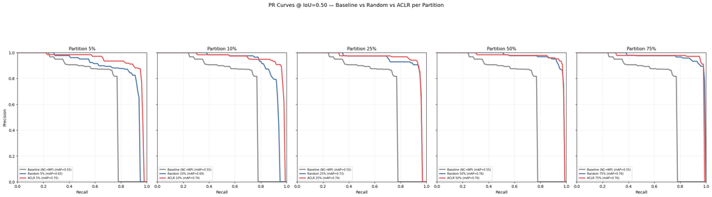

## Area Size of predictions

[1] D. Hoiem, Y. Chodpathumwan, and Q. Dai, **‘Diagnosing Error in Object Detectors’**, in Computer Vision – ECCV 2012, vol. 7574, A. Fitzgibbon, S. Lazebnik, P. Perona, Y. Sato, and C. Schmid, Eds, in Lecture Notes in Computer Science, vol. 7574. , Berlin, Heidelberg: Springer Berlin Heidelberg, 2012, pp. 340–353. doi: 10.1007/978-3-642-33712-3_25.

```
Percentile thresholds (relative area):
  p10 = 0.000309  (×10⁻³: 0.3086)
  p30 = 0.000549  (×10⁻³: 0.5493)
  p70 = 0.001351  (×10⁻³: 1.3508)
  p90 = 0.002235  (×10⁻³: 2.2345)

Category counts:
  XS:  360  (10.0%)
  S:  724  (20.0%)
  M: 1446  (40.0%)
  L:  723  (20.0%)
  XL:  362  (10.0%)
```

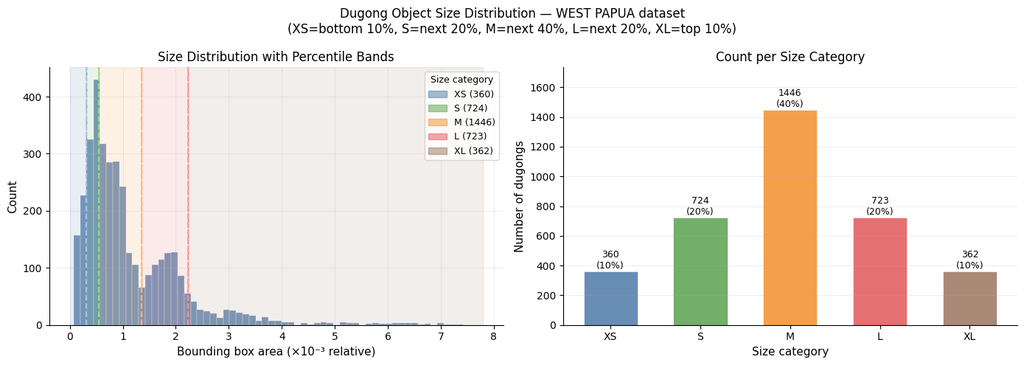

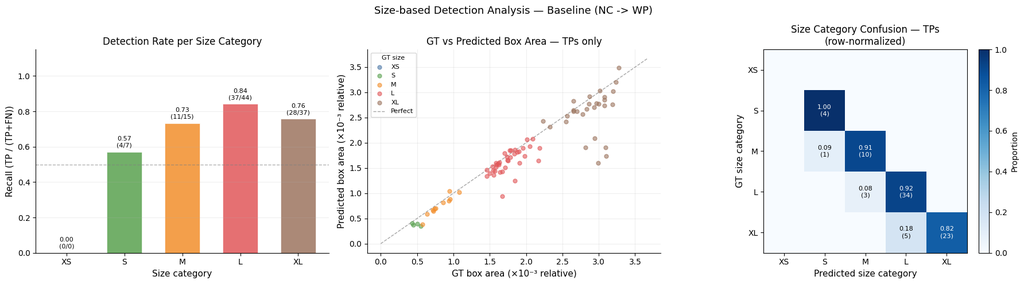

[figure not shown]

```
Baseline (NC→WP)
  TP areas — mean: 0.00125, median: 0.00103, n=56
  FN areas — mean: 0.00104, median: 0.00073, n=49

Fine-tuned
  TP areas — mean: 0.00136, median: 0.00141, n=72
  FN areas — mean: 0.00070, median: 0.00048, n=33

Fine-tuned + ACLR
  TP areas — mean: 0.00136, median: 0.00140, n=75
  FN areas — mean: 0.00064, median: 0.00047, n=30
```

## Confidence Score Distribution

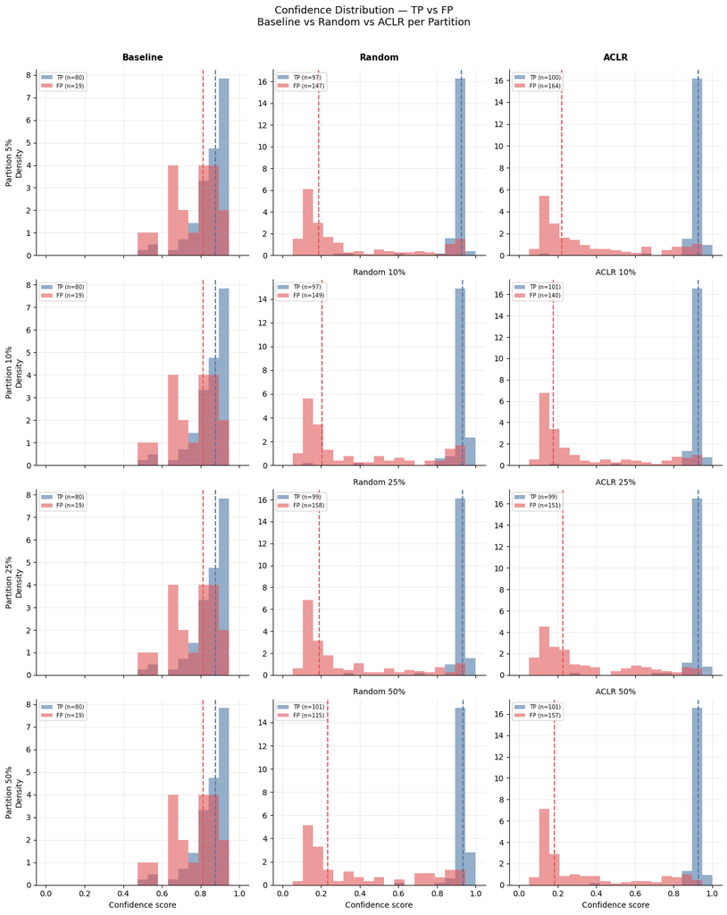

### FP TP FN count

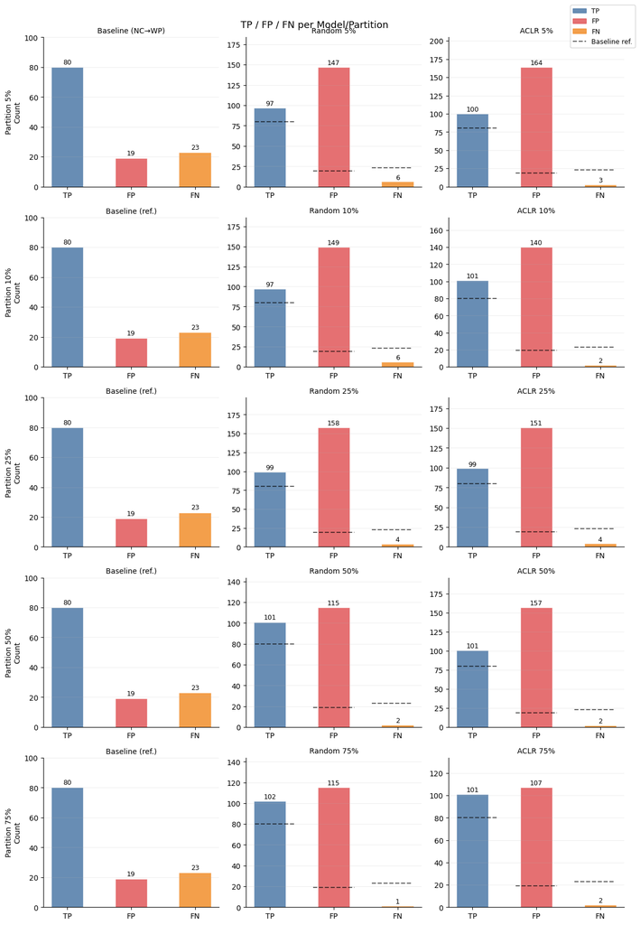